# Confidence interval

## Example 7.6 (textbook)

Haven’t you always wanted to own a Porsche? The author thought maybe he could afford a Boxster, the cheapest model. So he went to www.cars.com on Nov. 18, 2009, and found a total of 1113 such cars listed. Asking prices ranged from $3499 to $130,000 (the latter price was one of only two exceeding $70,000). The prices depressed him, so he focused instead on odometer readings (miles). Here are reported readings for a sample of 50 of these Boxsters:

```r
dat1=c(2948, 2996, 7197, 8338, 8500, 8759, 12710, 12925,
15767, 20000, 23247, 24863, 26000, 26210, 30552, 30600,
35700, 36466, 40316, 40596, 41021, 41234, 43000, 44607,
45000, 45027, 45442, 46963, 47978, 49518, 52000, 53334,
54208, 56062, 57000, 57365, 60020, 60265, 60803, 62851,
64404, 72140, 74594, 79308, 79500, 80000, 80000, 84000,
113000, 118634)
```

Find 95% Confidence interval for sample mean

```r
 muX=mean(dat1) #find the sample mean
stdX=sd(dat1) #find standard deviation of X
z=qnorm(0.975) # find  0.975 quantile of the normal distribution (z_0.025)
n=length(dat1)
Lbound=muX-z*stdX/sqrt(n)#lower bound of the CI
Ubound=muX+z*stdX/sqrt(n)#upper bound of the CI
(ci=c(Lbound, Ubound))
```

```
## [1] 38294.80 53063.92
```

Find One sided interval

```r
stdX=sd(dat1) #find standard deviation of X
zalpha=qnorm(0.95) # find  0.95 quantile of the normal distribution (z_0.05)
n=length(dat1)
(Ubound=muX+zalpha*stdX/sqrt(n))#Upper bound of the CI
```

```
## [1] 51876.68
```

## Example 7.11 (text book)

Even as traditional markets for sweetgum lumber have declined, large section solid timbers traditionally used for construction bridges and mats have become increasingly scarce. The article “Development of Novel Industrial Laminated Planks from Sweetgum Lumber” (J. of Bridge Engr., 2008: 64-66) described the manufacturing and testing of composite beams designed to add value to low-grade sweetgum lumber Here is data on the modulus of rupture (psi; the article contained summary data expressed in MPa):

```r
dat=c(6807.99, 7637.06, 6663.28, 6165.03, 6991.41, 6992.23,
      6981.46, 7569.75, 7437.88, 6872.39, 7663.18, 6032.28,
      6906.04, 6617.17, 6984.12, 7093.71, 7659.50, 7378.61,
      7295.54, 6702.76, 7440.17, 8053.26, 8284.75, 7347.95,
      7422.69, 7886.87, 6316.67, 7713.65, 7503.33, 7674.99)
```

Check Normality of the data

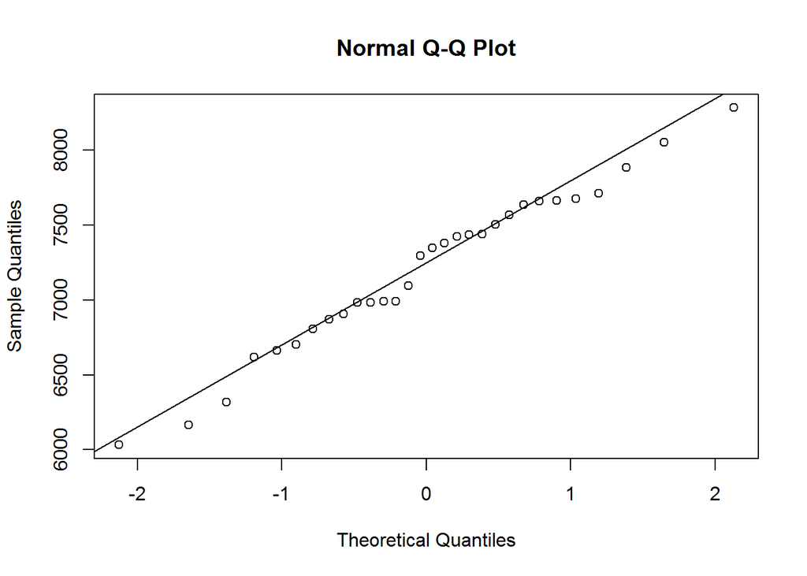

```r
qqnorm(dat)
qqline(dat)
```

Consttruch 95% Confidence interval

```r
muX=mean(dat) #find the sample mean
n=length(dat)
stdX=sd(dat) #find standard deviation of X
tt=qt(0.975,n-1) # find  0.975 quantile of the normal distribution (z_0.025)

Lbound=muX-tt*stdX/sqrt(n)#low bound of the CI
Ubound=muX+tt*stdX/sqrt(n)#Upper bound of the CI
( ci=c(Lbound, Ubound))
```

```
## [1] 7000.230 7406.152
```

Another way to do it

```r
t.test(dat)
```

```
##
##  One Sample t-test
##
## data:  dat
## t = 72.586, df = 29, p-value < 2.2e-16
## alternative hypothesis: true mean is not equal to 0
## 95 percent confidence interval:
##  7000.230 7406.152
## sample estimates:
## mean of x
##  7203.191
```